# Topics_2

Domagoj Fizulic

May 20, 2016

# Question 1

Power 1 is the black line. Other colors are powers 2-5.

## Apple

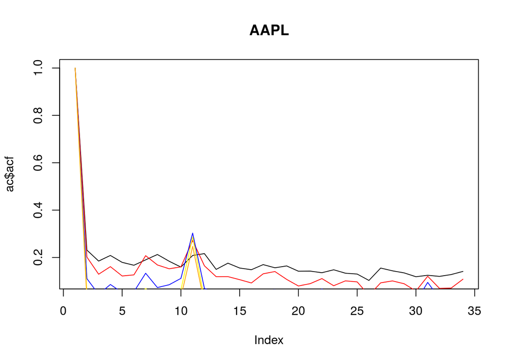

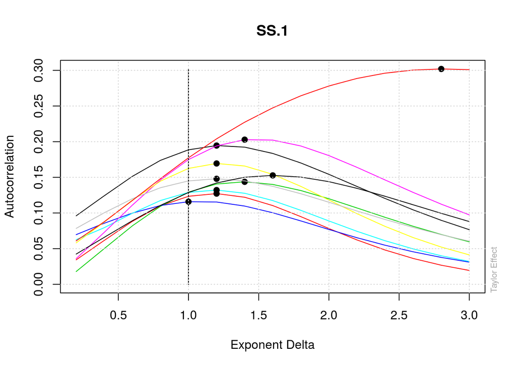

## Google

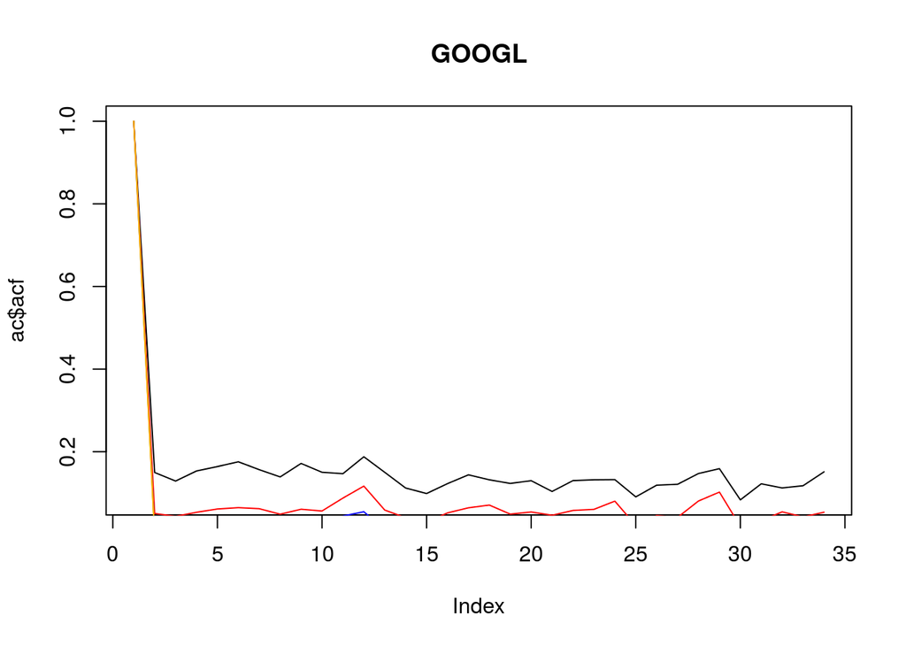

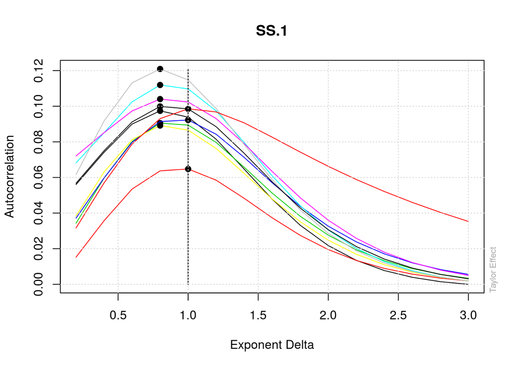

## S&P 500

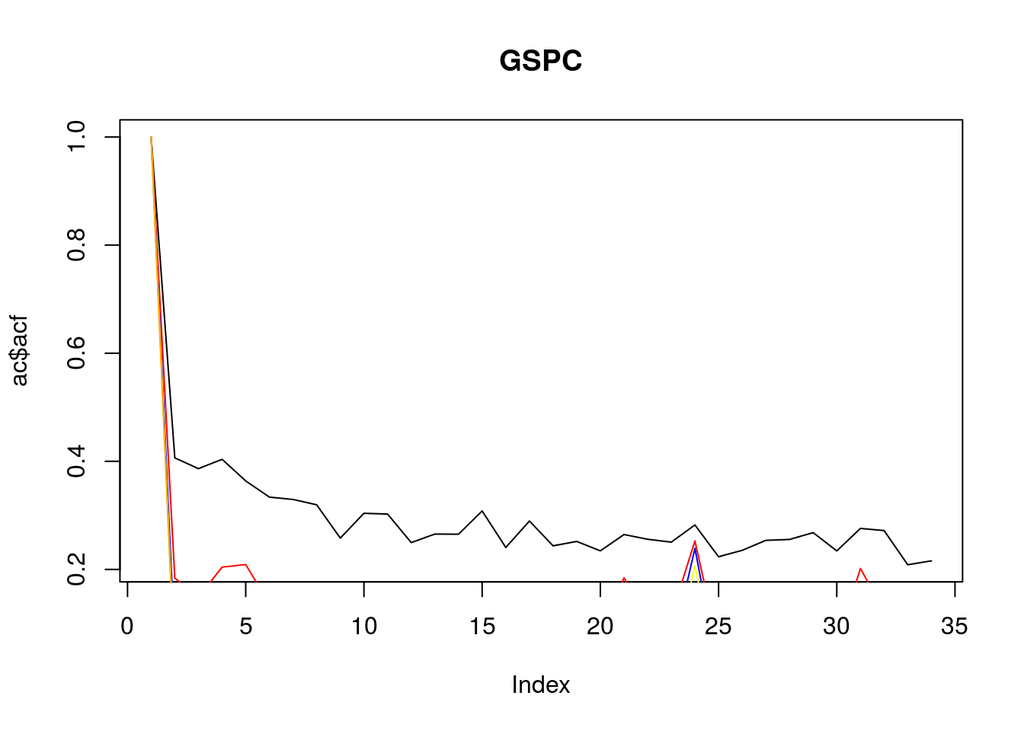

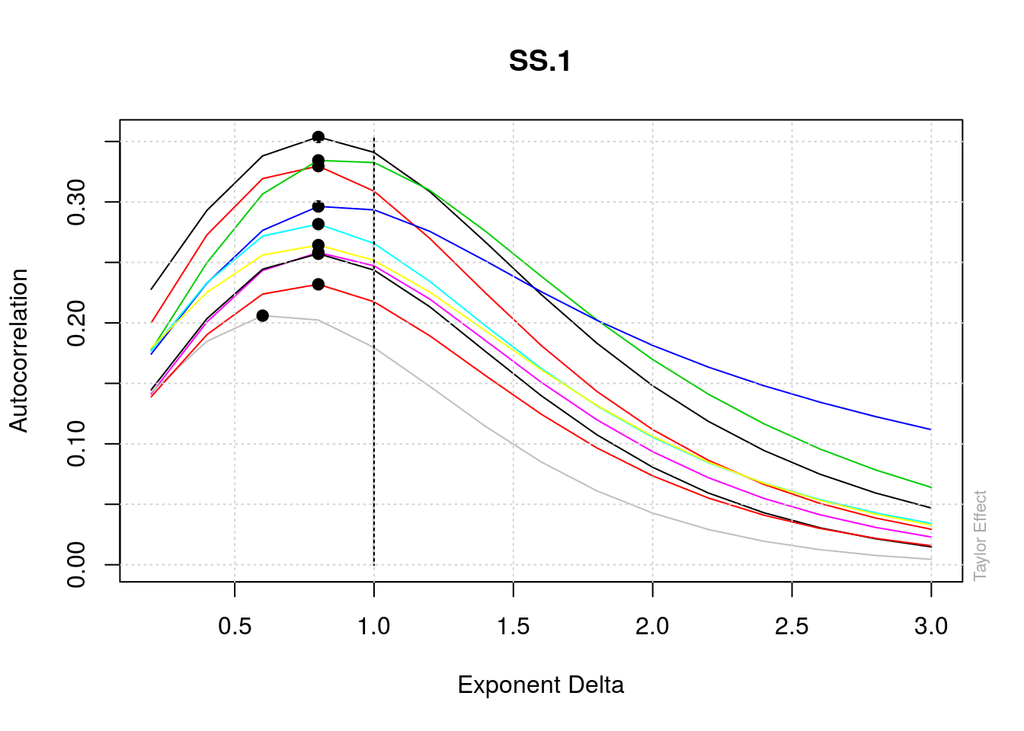

# Question 2

```
## [1] "UMCSENT"
```

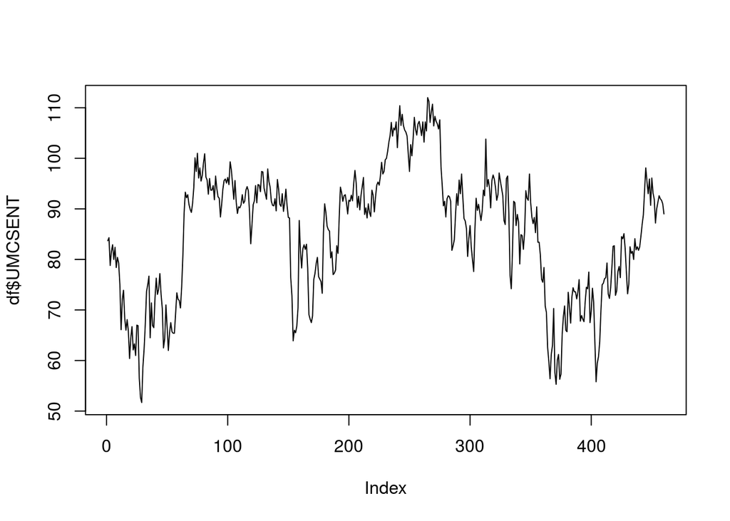

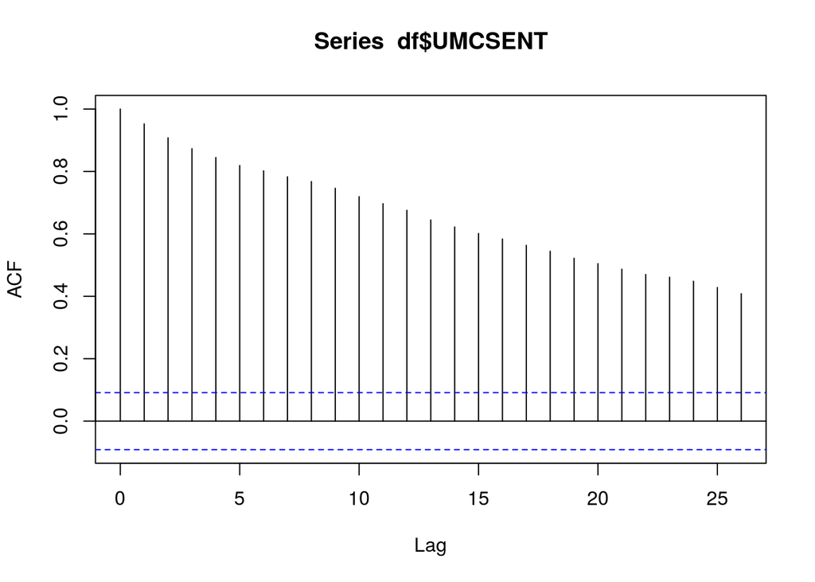

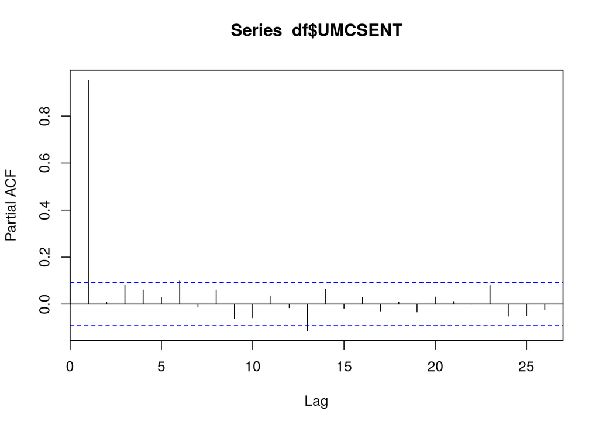

From above plots we ca see the data is not stationary. Confirm with Dickey-Fuller.

```
##
##  Augmented Dickey-Fuller Test
##
## data:  df$UMCSENT
## Dickey-Fuller = -2.2297, Lag order = 7, p-value = 0.4808
## alternative hypothesis: stationary
```

## Difference the data

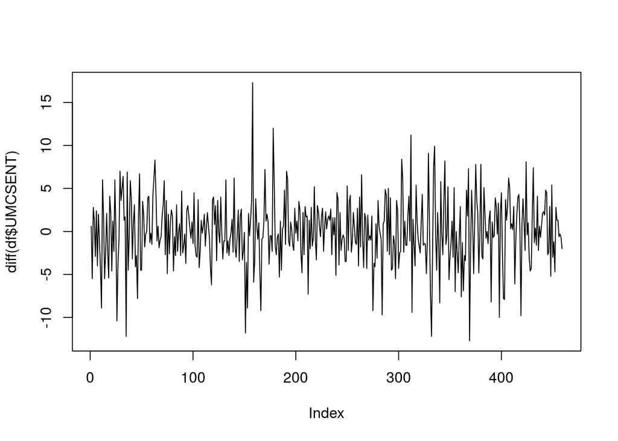

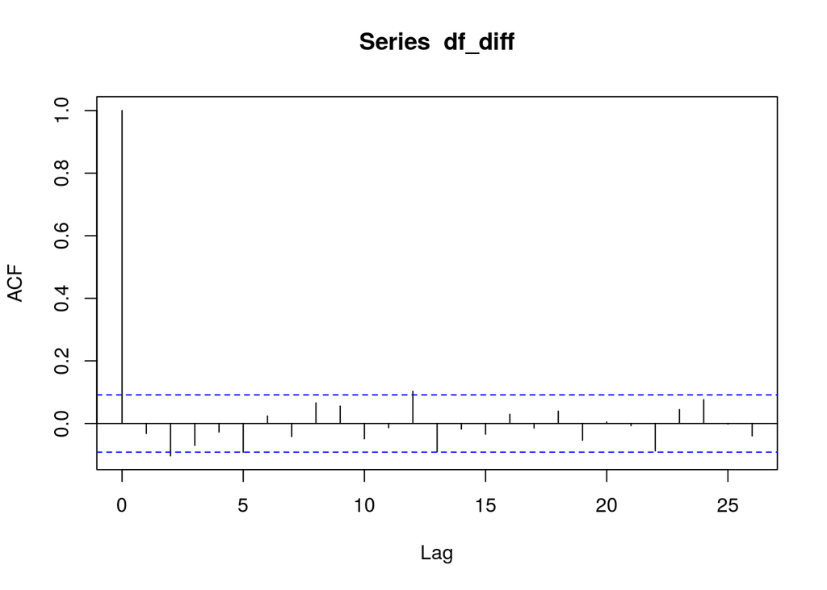

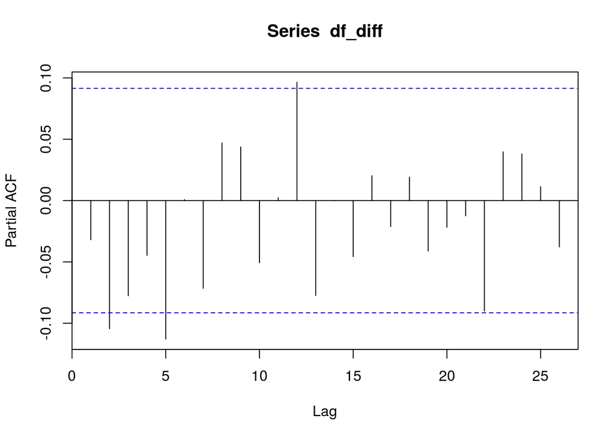

```
##
##  Augmented Dickey-Fuller Test
##
## data:  df_diff
## Dickey-Fuller = -8.5761, Lag order = 7, p-value = 0.01
## alternative hypothesis: stationary
```

## Auto ARIMA wrt AIC

```
## Series: df_diff
## ARIMA(1,0,2) with zero mean
##
## Coefficients:
##          ar1      ma1      ma2
##       0.5755  -0.6311  -0.0934
## s.e.  0.1735   0.1753   0.0567
##
## sigma^2 estimated as 15.22:  log likelihood=-1274.73
## AIC=2557.45   AICc=2557.54   BIC=2573.97
```

## Square of returns of UMCSENT

## ACF & PACF

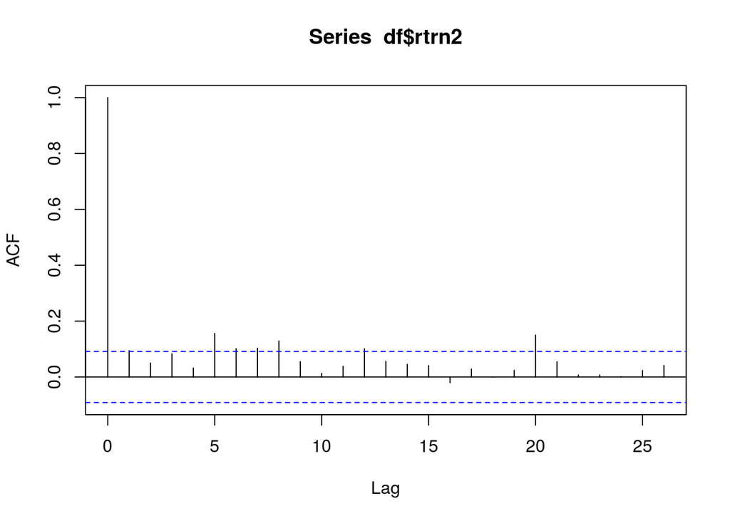

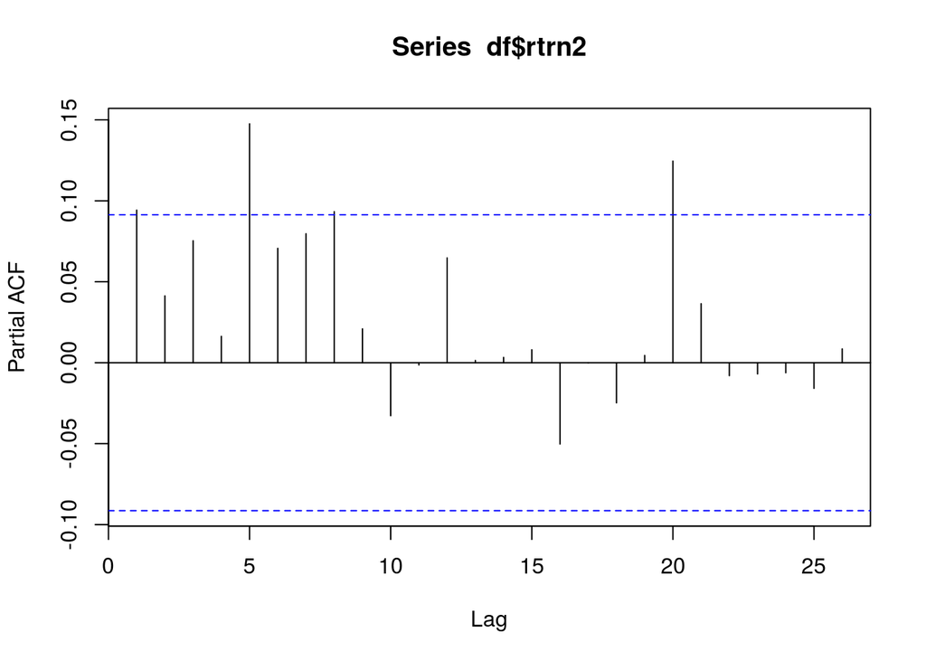

## Ljung-Box

```
##
##  Box-Ljung test
##
## data:  df$rtrn2
## X-squared = 4.1121, df = 1, p-value = 0.04258
```

## ARMA-GARCH

```
##
## Title:
##  GARCH Modelling
##
## Call:
##  garchFit(formula = ~arma(1, 1) + garch(1, 1), data = df$rtrn)
##
## Mean and Variance Equation:
##  data ~ arma(1, 1) + garch(1, 1)
## <environment: 0x4356300>
##  [data = df$rtrn]
##
## Conditional Distribution:
##  norm
##
## Coefficient(s):
##          mu          ar1          ma1        omega       alpha1
##  5.9427e-04   7.1608e-01  -8.3085e-01   5.9467e-05   9.6843e-02
##       beta1
##  8.8138e-01
##
## Std. Errors:
##  based on Hessian
##
## Error Analysis:
##          Estimate  Std. Error  t value Pr(>|t|)
## mu      5.943e-04   3.937e-04    1.510   0.1312
## ar1     7.161e-01   1.236e-01    5.791 6.98e-09 ***
## ma1    -8.309e-01   9.848e-02   -8.437  < 2e-16 ***
## omega   5.947e-05   2.914e-05    2.041   0.0413 *
## alpha1  9.684e-02   2.418e-02    4.004 6.22e-05 ***
## beta1   8.814e-01   2.551e-02   34.545  < 2e-16 ***
## ---
## Signif. codes:  0 '***' 0.001 '**' 0.01 '*' 0.05 '.' 0.1 ' ' 1
##
## Log Likelihood:
##  756.3255    normalized:  1.644186
##
## Description:
##  Fri May 20 21:59:10 2016 by user:
##
##
## Standardised Residuals Tests:
##                                 Statistic p-Value
##  Jarque-Bera Test   R    Chi^2  38.84378  3.674355e-09
##  Shapiro-Wilk Test  R    W      0.9859023 0.0001941893
##  Ljung-Box Test     R    Q(10)  6.85387   0.7391647
##  Ljung-Box Test     R    Q(15)  15.44574  0.4198112
##  Ljung-Box Test     R    Q(20)  17.9869   0.5882716
##  Ljung-Box Test     R^2  Q(10)  10.41021  0.4052708
##  Ljung-Box Test     R^2  Q(15)  11.73229  0.6991689
##  Ljung-Box Test     R^2  Q(20)  17.89932  0.5940406
##  LM Arch Test       R    TR^2   10.56445  0.566567
##
## Information Criterion Statistics:
##       AIC       BIC       SIC      HQIC
## -3.262285 -3.208399 -3.262619 -3.241066
```

# Question 3

## NN dividend/price (5 lags for all cases)

```
## $folds
## [1] 0.001811215 0.001365793 0.001792039 0.001544860 0.001277477
##
## $average
## [1] 0.001558277
```

## NN PE10

```
## $folds
## [1] 0.001550870 0.002073239 0.001185960 0.001461064 0.001698527
##
## $average
## [1] 0.001593932
```

## NN dividend/price + PE10

```
## $folds
## [1] 0.001509842 0.002206664 0.001198036 0.001593195 0.001453325
##
## $average
## [1] 0.001592212
```

## SVM dividend/price

```
## $folds
## [1] 0.001822501 0.001404041 0.001825733 0.001516574 0.001294497
##
## $average
## [1] 0.001572669
```

## SVM PE10

```
## $folds
## [1] 0.001481373 0.002079052 0.001300448 0.001525307 0.001741522
##
## $average
## [1] 0.00162554
```

## SVM dividend/price + PE10

```
## $folds
## [1] 0.001456985 0.002229145 0.001223836 0.001643663 0.001507885
##
## $average
## [1] 0.001612303
```

## Tuning Code

```r
## h2o deep learning
library(h2o)
localH2O = h2o.init(nthreads=-1)

data_train_h <- as.h2o(data_train,destination_frame = "h2o_data_train")
data_test_h <- as.h2o(data_test,destination_frame = "h2o_data_test")


y <- "target"
x <- setdiff(names(data_train_h), y)


#grid search
hidden_opt <- list(c(200,200), c(100,300,100), c(500,500,500))
l1_opt <- c(1e-5,1e-7)
hyper_params <- list(hidden = hidden_opt, l1 = l1_opt)

model_grid <- h2o.grid("deeplearning",
                        hyper_params = hyper_params,
                        x = (2:ncol(data_train_h)),
                        y = 1,
                        #distribution = "multinomial",
                        training_frame = data_train_h,
                        validation_frame = data_test_h)

# print out the Test MSE for all of the models
for (model_id in model_grid@model_ids) {
  model <- h2o.getModel(model_id)
  mse <- h2o.mse(model, valid = TRUE)
  #mse <- h2o.mse(model, valid = FALSE)
  print(sprintf("Test set MSE: %f", mse))
}

h2o.shutdown()

## SVM

# set up the cross-validated hyper-parameter search
svm_grid_1 = expand.grid(
  cost = 10^c(-1,0.5,1.5,2,3,4),
  gamma = 10^c(-3,-2,-1,0,1,2,3)
)

svm_grid_2 = expand.grid(
  cost = 0.11,
  gamma = 0.01
)

# pack the training control parameters
svm_trcontrol_1 = trainControl(
  method = "cv",
  number = 5,
  verboseIter = TRUE,
  returnData = FALSE,
  returnResamp = "all",               # save losses across all models
  #classProbs = TRUE,                  # set to TRUE for AUC to be computed
  #summaryFunction = twoClassSummary,
  summaryFunction = defaultSummary,
  allowParallel = TRUE
)

svm_train_0 = train(
  x = trainset[,-1],
  y = trainset[,1],
  trControl = svm_trcontrol_1,
  tuneGrid = svm_grid_2,
  method = "svmLinear2"
  #kernel = "radial", #radial is default
  #type="eps-regression"
)
```

# Question 4

# Question 5

## Variance of Portfolio Return

Key Concepts:

1. $\rho_{ii}\;=\;1 \forall i \in \{ 1, 2 .... n \}$
2. $\rho_{ij}\;= \;\rho_{ji}\;=\;\frac{\mathrm{Cov(X_{i}, X_{j})}}{\sigma_{i} \sigma_{j}} \implies \sigma_{i} \sigma_{j} \rho_{ij}\;=\;Cov(X_{i}, X_{j})$

We begin by looking at the variance when the value of n is 2.

$Var(a_{1}X_{1} + a_{2}X_{2})\;=\; Var(a_{1}X_{1})\;+\;Var(a_{2}X_{2})\;+\;2Cov(a_{1}X_{1}, a_{2}X_{2})$

$\hspace{1.20in}\;=\; a_{1}^{2}Var(X_{1})\;+\;a_{2}^{2}Var(X_{2})\;+\;2a_{1}a_{2}Cov(X_{1}, X_{2})$

$\hspace{1.20in}\;=\; a_{1}^{2}\sigma_{1}^{2}\;+\;a_{2}^{2}\sigma_{2}^{2}\;+\;2a_{1}a_{2}\sigma_{1} \sigma_{1} \rho_{12}$

$\hspace{1.20in}\;=\;a_{1}^{2}\sigma_{1}^{2}\;+\;a_{1}a_{2}\sigma_{1} \sigma_{1} \rho_{12}\;+\;a_{2}^{2}\sigma_{2}^{2}\;+\;a_{2}a_{1}\sigma_{2} \sigma_{1} \rho_{21}$

$\hspace{1.20in}\;=\;a_{1}a_{1}\sigma_{1}\sigma_{1}\rho_{11}\;+\;a_{1}a_{2}\sigma_{1} \sigma_{1} \rho_{12}\;+\;a_{2}a_{2}\sigma_{2}\sigma_{2}\rho_{22}\;+\;a_{2}a_{1}\sigma_{2} \sigma_{1} \rho_{21}$

$\hspace{1.20in}\;=\;\sum_{j = 1}^{2} a_{1}a_{j}\sigma_{1}\sigma_{j}\rho_{1j}\;+\;\sum_{j = 1}^{2} a_{2}a_{j}\sigma_{2}\sigma_{j}\rho_{2j}$

$\hspace{1.20in}\;=\;\sum_{i = 1}^{2}\sum_{j = 1}^{2} a_{i}a_{j}\sigma_{i}\sigma_{j}\rho_{ij}$

Now, Assume the formula holds for some unspecified value of n = k. It must then be shown that the formula holds for n = k+1, that is:

$Var\left(\sum_{i = 1}^{k+1} a_{i}X_{i}\right)\;=\; \sum_{i = 1}^{k+1}\sum_{j = 1}^{k+1} a_{i}a_{j}\sigma_{i}\sigma_{j}\rho_{ij}$

Using the induction hypothesis that the formula holds for n = k, the left-hand side can be rewritten to:

$Var\left(\sum_{i = 1}^{k+1} a_{i}X_{i}\right)\;=\; Var\left(\sum_{i = 1}^{k} a_{i}X_{i} + a_{k+1}X_{k+1}\right)$

$\hspace{1.14in}\;=\; \sum_{i = 1}^{k}\sum_{j = 1}^{k} a_{i}a_{j}\sigma_{i}\sigma_{j}\rho_{ij} + Var(a_{k+1}X_{k+1})\;+\;2Cov(\sum_{i = 1}^{k} a_{i}X_{i},a_{k+1}X_{k+1})$

$\hspace{1.14in}\;=\; \sum_{i = 1}^{k}\sum_{j = 1}^{k} a_{i}a_{j}\sigma_{i}\sigma_{j}\rho_{ij} + a_{k+1}a_{k+1}\sigma_{k+1}\sigma_{k+1}\rho_{k+1k+1}\;+\;2\sum_{i = 1}^{k}Cov( a_{i}X_{i},a_{k+1}X_{k+1})$

$\hspace{1.14in}\;=\; \sum_{i = 1}^{k}\sum_{j = 1}^{k} a_{i}a_{j}\sigma_{i}\sigma_{j}\rho_{ij} + a_{k+1}a_{k+1}\sigma_{k+1}\sigma_{k+1}\rho_{k+1k+1}\;+\;2\sum_{i = 1}^{k}a_{i}a_{k+1}\sigma_{i}\sigma_{k+1}\rho_{ik+1}$

$\hspace{1.14in}\;=\; \sum_{i = 1}^{k+1}\sum_{j = 1}^{k+1} a_{i}a_{j}\sigma_{i}\sigma_{j}\rho_{ij}$

Hence,

$Var\left(\sum_{i = 1}^{2} a_{i}X_{i}\right)\;=\; \sum_{i = 1}^{2}\sum_{j = 1}^{2} a_{i}a_{j}\sigma_{i}\sigma_{j}\rho_{ij}$

$Var\left(\sum_{i = 1}^{k+1} a_{i}X_{i}\right)\;=\; \sum_{i = 1}^{k+1}\sum_{j = 1}^{k+1} a_{i}a_{j}\sigma_{i}\sigma_{j}\rho_{ij}$

We can generalize the above result to n terms and conclude:

$Var\left(\sum_{i = 1}^{n} a_{i}X_{i}\right)\;=\; \sum_{i = 1}^{n}\sum_{j = 1}^{n} a_{i}a_{j}\sigma_{i}\sigma_{j}\rho_{ij}$

# Question 6

## Linear Regression on Information Set

Our objective is to prove that the best estimator for $X_{t + h}$ with information set $Z\;=\;\left(X_{t}, X_{t - 1}, ... X_{t - p}\right)$ when all variables follow $X \;\sim\; N(0,1)$ is a linear regression on Z.

We use $\Sigma$ to denote the variance-covariance matrix of $X_{t + h}$ and $Z$.

$\Sigma\;=\;\mathbb{E}\left[\left(X_{t+h} - \mathbb{E}\left[X_{t + H}\right]\right)^{T}\left(Z - \mathbb{E}\left[Z\right]\right)\right]$

$\hspace{0.15in}\;=\;\mathbb{E}\left[(X_{t + h} - 0)^{T}(Z - 0)\right]$

$\hspace{0.15in}\;=\;\mathbb{E}\left[(X_{t + h}^{T}Z\right]$

Our estimate for $X_{t+h}|Z$ is $\mathbb{E}\left[X_{t + h} | Z\right]$

$\mathbb{E}\left[X_{t + h} | Z\right]\;=\;\mathbb{E}X_{t + h}\;+\; \Sigma(\sigma_{Z}^{2})^{-1}\left(Z - \mathbb{E}Z\right)$

$\hspace{0.7in}\;=\;0\;+\;\mathbb{E}\left[X_{t+h}^{T}Z\right]\mathbb{E}\left[Z - \mathbb{E}Z\right]^{-2}\left(Z - 0\right)$

$\hspace{0.7in}\;=\;\mathbb{E}\left[X_{t+h}^{T}Z\right]\mathbb{E}\left[Z^{T}Z\right]^{-1}Z$

The above is a linear regression on $Z$, where $Z$ has the form $Z\;=\;\beta Z\;+\;\epsilon$ where $\beta\;=\;\mathbb{E}\left[X_{t+h}^{T}Z\right]\mathbb{E}\left[Z^{T}Z\right]^{-1}$